**AML2019**

### Challenge 1

# House Pricing Prediction

*22<sup>th</sup> March 2019*

The first AML challenge for this year is adapted from the well-known '*Zillow's Home Value Prediction*' competition on Kaggle. In particular, given a dataset containing descriptions of homes on the US property market, your task is to make predictions on the selling price of as-yet unlisted properties. Developing a model which accurately fits the available training data while also generalising to unseen data-points is a multi-faceted challenge that involves a mixture of data exploration, pre-processing, model selection, and performance evaluation.

# Overview

Beyond simply producing a well-performing model for making predictions, in this challenge we would like you to start developing your skills as a machine learning scientist. In this regard, your notebook should be structured in such a way as to explore the five following tasks that are expected to be carried out whenever undertaking such a project. The description below each aspect should serve as a guide for your work, but you are strongly encouraged to also explore alternative options and directions. Thinking outside the box will always be rewarded in these challenges.

### 1. Data Exploration

The first broad component of your notebook should enable you to familiarise yourselves with the given data, an outline of which is given at the end of this challenge specification. Among others, this section should investigate:

- Data cleaning, e.g. treatment of categorial variables;
- Data visualisation;
- Computing descriptive statistics, e.g. correlation.
- etc.

### 2. Data Pre-processing

The previous step should give you a better understanding of which pre-processing is required for the data. This may include:

- Normalising and standardising the given data;
- Removing outliers;
- Carrying out feature selection, possibly using metrics derived from information theory;
- Handling missing information in the dataset;
- Augmenting the dataset with external information;
- Combining existing features.

### 3. Model Selection

Perhaps the most important segment of this challenge involves the selection of a model that can successfully handle the given data and yield sensible predictions. Instead of focusing exclusively on your final chosen model, it is also important to share your thought process in this notebook by additionally describing alternative candidate models. There is a wealth of models to choose from, such as *decision trees*, *random forests*, *(Bayesian) neural networks*, *Gaussian processes*, *LASSO regression*, and so on. There are several factors which may influence your decision:

- What is the model's complexity?
- Is the model interpretable?
- Is the model capable of handling different data-types?
- Does the model return uncertainty estimates along with predictions?

An in-depth evaluation of competing models in view of this and other criteria will elevate the quality of your submission and earn you a higher grade.

### 4. Parameter Optimisation

Irrespective of your choice, it is highly likely that your model will have one or more parameters that require tuning. There are several techniques for carrying out such a procedure, including cross-validation, Bayesian optimisation, and several others. As before, an analysis into which parameter tuning technique best suits your model is expected before proceeding with the optimisation of your model.

### 5. Model Evaluation

Some form of pre-evaluation will inevitably be required in the preceding sections in order to both select an appropriate model and configure its parameters appropriately. In this final section, you may evaluate other aspects of the model such as:

- Assessing the running time of your model;
- Determining whether some aspects can be parallelised;
- Training the model with smaller subsets of the data.
- etc.

**N.B.** Please note that the items listed under each heading are neither exhaustive, nor are you expected to explore every given suggestion. Nonetheless, these should serve as a guideline for your work in both this and upcoming challenges. As always, you should use your intuition and understanding in order to decide which analysis best suits the assigned task.

## Submission Instructions

- The goal of this challenge is to construct a model for predicting house prices;
- Your submission will have two components:
  1. An **HTML version of your notebook** exploring the various modelling aspects described above;
  2. A CSV file containing your **final model's predictions on the given test data**. This file should contain a header and have the following format:

     ```
      Id,SalePrice
      1461,169000.1
      1462,187724.1233
      1463,175221
      etc.
     ```

     An example submission file has been provided in the data directory of the repository. A leaderboard for this challenge will be ranked using the root mean squared error between the logarithm of the predicted value and the logarithm of the observed sales price. Taking logs ensures that errors in predicting expensive houses and cheap houses will have a similar impact on the overall result;
- This exercise is due on **04/04/2019**.

## Dataset Description

#### * Files

- train.csv - The training dataset;
- test.csv - The test dataset;
- data_description.txt - Full description of each column.

#### * Attributes

A brief outline of the available attributes is given below:

- *SalePrice*: The property's sale price in dollars. This is the target variable that your model is intended to predict;
- *MSSubClass*: The building class;
- *MSZoning*: The general zoning classification;
- *LotFrontage*: Linear feet of street connected to property;
- *LotArea*: Lot size in square feet;
- *Street*: Type of road access;
- *Alley*: Type of alley access;
- *LotShape*: General shape of property;
- *LandContour*: Flatness of the property;
- *Utilities*: Type of utilities available;
- *LotConfig*: Lot configuration;
- *LandSlope*: Slope of property;
- *Neighborhood*: Physical locations within Ames city limits;
- *Condition1*: Proximity to main road or railroad;
- *Condition2*: Proximity to main road or railroad (if a second is present);
- *BldgType*: Type of dwelling;
- *HouseStyle*: Style of dwelling;
- *OverallQual*: Overall material and finish quality;
- *OverallCond*: Overall condition rating;
- *YearBuilt*: Original construction date;
- *YearRemodAdd*: Remodel date;
- *RoofStyle*: Type of roof;
- *RoofMatl*: Roof material;
- *Exterior1st*: Exterior covering on house;
- *Exterior2nd*: Exterior covering on house (if more than one material);
- *MasVnrType*: Masonry veneer type;
- *MasVnrArea*: Masonry veneer area in square feet;
- *ExterQualv*: Exterior material quality;
- *ExterCond*: Present condition of the material on the exterior;
- *Foundation*: Type of foundation;
- *BsmtQual*: Height of the basement;
- *BsmtCond*: General condition of the basement;
- *BsmtExposure*: Walkout or garden level basement walls;
- *BsmtFinType1*: Quality of basement finished area;
- *BsmtFinSF1*: Type 1 finished square feet;
- *BsmtFinType2*: Quality of second finished area (if present);
- *BsmtFinSF2*: Type 2 finished square feet;
- *BsmtUnfSF*: Unfinished square feet of basement area;
- *TotalBsmtSF*: Total square feet of basement area;
- *Heating*: Type of heating;
- *HeatingQC*: Heating quality and condition;
- *CentralAir*: Central air conditioning;
- *Electrical*: Electrical system;
- *1stFlrSF*: First Floor square feet;
- *2ndFlrSF*: Second floor square feet;
- *LowQualFinSF*: Low quality finished square feet (all floors);
- *GrLivArea*: Above grade (ground) living area square feet;
- *BsmtFullBath*: Basement full bathrooms;
- *BsmtHalfBath*: Basement half bathrooms;
- *FullBath*: Full bathrooms above grade;
- *HalfBath*: Half baths above grade;
- *Bedroom*: Number of bedrooms above basement level;
- *Kitchen*: Number of kitchens;
- *KitchenQual*: Kitchen quality;
- *TotRmsAbvGrd*: Total rooms above grade (does not include bathrooms);
- *Functional*: Home functionality rating;
- *Fireplaces*: Number of fireplaces;
- *FireplaceQu*: Fireplace quality;
- *GarageType*: Garage location;
- *GarageYrBlt*: Year garage was built;
- *GarageFinish*: Interior finish of the garage;
- *GarageCars*: Size of garage in car capacity;
- *GarageArea*: Size of garage in square feet;
- *GarageQual*: Garage quality;
- *GarageCond*: Garage condition;
- *PavedDrive*: Paved driveway;
- *WoodDeckSF*: Wood deck area in square feet;
- *OpenPorchSF*: Open porch area in square feet;
- *EnclosedPorch*: Enclosed porch area in square feet;
- *3SsnPorch*: Three season porch area in square feet;
- *ScreenPorch*: Screen porch area in square feet;
- *PoolArea*: Pool area in square feet;
- *PoolQC*: Pool quality;
- *Fence*: Fence quality;
- *MiscFeature*: Miscellaneous feature not covered in other categories;
- *MiscVal*: Value (in dollars) of miscellaneous feature;
- *MoSold*: Month sold;
- *YrSold*: Year sold;
- *SaleType*: Type of sale;
- *SaleCondition*: Condition of sale.

```python
%matplotlib inline
import os
import sys
import re
import random
import matplotlib
import math
import matplotlib.pyplot as plt
import pandas as pd
import numpy as np
import seaborn as sns
from time import time
from sklearn.ensemble import RandomForestClassifier
from sklearn.feature_selection import SelectFromModel
from sklearn.linear_model import LinearRegression
from sklearn.model_selection import train_test_split
import scipy.stats as ss
from sklearn.preprocessing import StandardScaler
```

# Data Exploration

## Data Analysis

First we start by loading our data. We then try to understand the state ofour dataset by seeing if we have any missing data. We can notice that with using pandas.Dataframe.info(), pandas confuses the two values NA and NaN: NA has a meaning for example for column Alley it means the house does't have an ally leading to it while NaN means empty values.

```python
#Load the data
train_data = pd.read_csv('challenge_data/train.csv')
test_data = pd.read_csv('challenge_data/test.csv')
```

We start by trying to understand the value of houses column. First we start by seeing an overall description of the Sale Prices.

```python
#descriptive statistics summary
train_data['SalePrice'].describe()
```

```
count      1200.000000
mean     181414.628333
std       81070.908544
min       34900.000000
25%      129900.000000
50%      163700.000000
75%      214000.000000
max      755000.000000
Name: SalePrice, dtype: float64
```

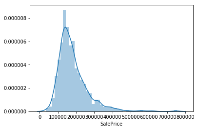

```python
sns.distplot(train_data['SalePrice'])
```

We can first notice that there is no visible anomalies about our data like negative or null prices, or missing values.  
Most of the house value are set in a range 215000.

To be able to estimate correlation between the different columns, we replace all alpha values by numerical values starting from 1. We replace then NA values by value 0. That way we keep only empty values are not of numerical type.

We print afterwards the mapping dictionnary for every feature.

```python
#list of categorical, continous and output columns
categorical= ["MSSubClass","MSZoning","Street","Alley","LotShape","LandContour","LotConfig","LandSlope",
              "Neighborhood","Condition1","Condition2","BldgType","HouseStyle","OverallQual","OverallCond","RoofStyle",
              "RoofMatl","Exterior1st","Exterior2nd","MasVnrType","MoSold","SaleType","SaleCondition",
              "PoolQC","Fence","MiscFeature",
              "GarageQual","GarageCond","PavedDrive","GarageFinish","GarageCars","BsmtFullBath","BsmtHalfBath","FullBath",
              "HalfBath","BedroomAbvGr","KitchenAbvGr","KitchenQual","TotRmsAbvGrd","Functional","Fireplaces","FireplaceQu",
              "GarageType","Heating","HeatingQC","CentralAir","Electrical","ExterQual","ExterCond","Foundation","BsmtQual",
              "BsmtCond","BsmtExposure","BsmtFinType1","BsmtFinType2"]
numeric =["LotFrontage","LotArea","YearBuilt","YearRemodAdd","MasVnrArea","MiscVal","GarageArea","GarageYrBlt","GrLivArea", "PoolArea",
         "WoodDeckSF","OpenPorchSF","EnclosedPorch","3SsnPorch","ScreenPorch","1stFlrSF","2ndFlrSF","LowQualFinSF","BsmtFinSF2",
          "BsmtUnfSF","TotalBsmtSF","BsmtFinSF1"]
output = ["SalePrice"]
#Map every columns to numerical values
for col in train_data.columns:
    if col in categorical:
        dict_={}
        i=1
        values = train_data[col].unique()
        for val in values:
            if type(val) == float:
                if math.isnan(val):
                    dict_[val]=0
                else:
                    dict_[val]= i
                    i+=1
            else:
                dict_[val]= i
                i+=1
        print(col,' ',dict_)
        train_data[col] = train_data[col].map(dict_)
        test_data[col] = test_data[col].map(dict_)
```

[output not shown]

We plot the relation between each feature and the output to see if there is any visible relation first and to detect outliers values.

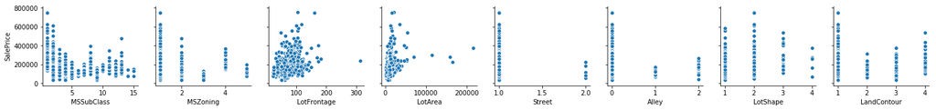

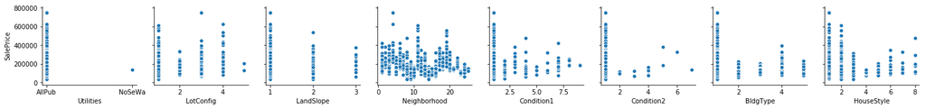

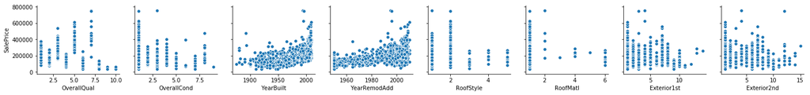

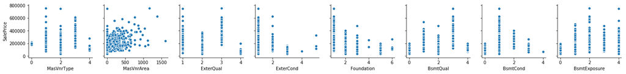

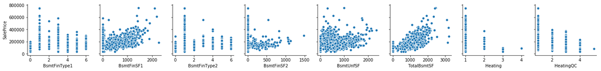

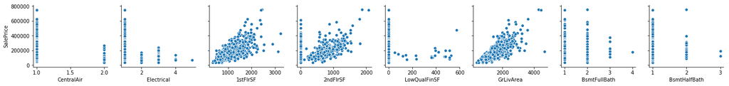

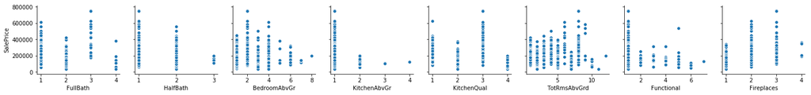

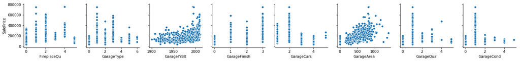

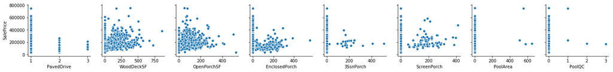

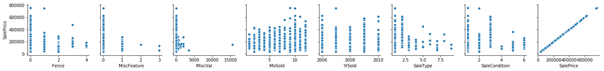

```python
i = 10
for i in range(10):
    l = 8*i+1
    u = 8*(i+1)+1
    sns.pairplot(train_data,y_vars=['SalePrice'],x_vars=train_data.columns[l:u])
```

# Data Preprocessing

## Outliers + Empty Values

The existense of twotypes of data obliges us to treat each seperatly. We can see that there are some continous features that are highly related to the Sale Price e.g. GrLivArea. Therefore we need todefine some metrics to evaluate the best features to use.  
Wecan also notice from continous variables plots that there are some outliers. Therefore we start by eliminate them to have a more coherent data.

```python
#Remove outliers
train_data_clean = train_data[train_data.LotFrontage<200]
train_data_clean = train_data_clean[train_data_clean.LotArea<10000]
train_data_clean = train_data_clean[train_data_clean.MasVnrArea<1500]
train_data_clean = train_data_clean[train_data_clean.TotalBsmtSF<3000]
train_data_clean = train_data_clean[train_data_clean.GrLivArea<4000]
train_data_clean = train_data_clean[train_data_clean.TotalBsmtSF<2000]
train_data_clean = train_data_clean[train_data_clean["1stFlrSF"]<2100]
train_data_clean = train_data_clean[train_data_clean.OpenPorchSF<400]
train_data_clean = train_data_clean[train_data_clean.EnclosedPorch<400]
train_data_clean = train_data_clean[train_data_clean.WoodDeckSF<500]
```

```python
#Remove rows with empty values in train data
train_data_clean = train_data_clean.dropna()
#We fill empty valus with mode of column in test data
test_data = test_data.fillna(test_data.mode().iloc[0])
#We remove 73 element to keep full data
```

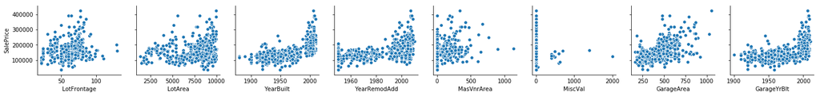

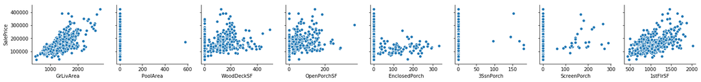

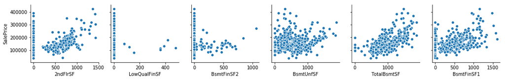

```python
#We plot continous variable pairpots repsective to Sale Price
sns.pairplot(train_data_clean,y_vars=['SalePrice'],x_vars=numeric[0:8])
sns.pairplot(train_data_clean,y_vars=['SalePrice'],x_vars=numeric[8:16])
sns.pairplot(train_data_clean,y_vars=['SalePrice'],x_vars=numeric[16:])
```

We notice that some variables like PoolArea, 3SsnPorch, LowQualFinSF won't add much information therefore we won't be considering them

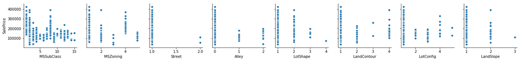

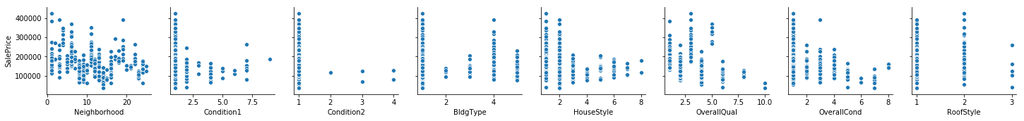

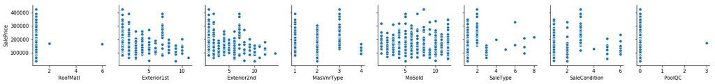

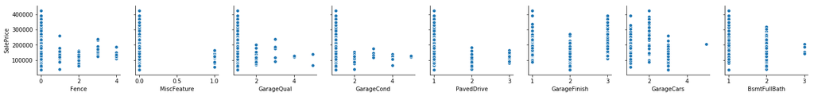

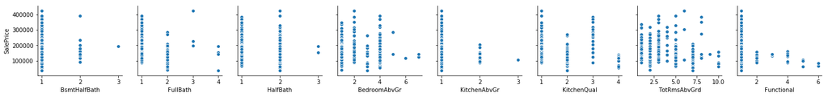

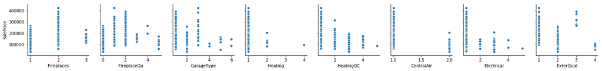

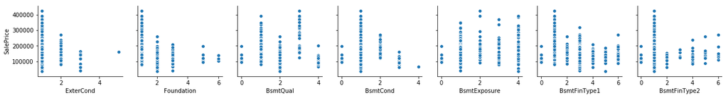

```python
#We plot categorical features pairplot respective to SalePrice
sns.pairplot(train_data_clean,y_vars=['SalePrice'],x_vars=categorical[0:8])
sns.pairplot(train_data_clean,y_vars=['SalePrice'],x_vars=categorical[8:16])
sns.pairplot(train_data_clean,y_vars=['SalePrice'],x_vars=categorical[16:24])
sns.pairplot(train_data_clean,y_vars=['SalePrice'],x_vars=categorical[24:32])
sns.pairplot(train_data_clean,y_vars=['SalePrice'],x_vars=categorical[32:40])
sns.pairplot(train_data_clean,y_vars=['SalePrice'],x_vars=categorical[40:48])
sns.pairplot(train_data_clean,y_vars=['SalePrice'],x_vars=categorical[48:])
```

The same reasi=oning is applied here. We remove thus Street, Condition2, RoofMatl, PoolQC and Heating

Now that we have processed our categorical variables, cleaned our continous variable, we need to extract most important features. We need to deal with categorical values and continous variable seperatly.

## Features Extraction

We consider our cleaned data (no outliers + no empty values).  
Now we make the statement that it has no valuable meaning to calculate Pearson correlation ( the default correlation using df.corr()) between :  
1)a Categorical variable and a Categorical variable.  
2)a Categorical variable and a Numeric variable.  
Therefore we use these metrics to calculate correlations between the different variables:

|  | Categorical | Continous |
| --- | --- | --- |
| Categorical | V Cramer's + Random Forest |  |
| Continous |  | Pearson + PCA |

V ramer's s a variante of the Chi-square test of dependancy of variables, Pearson is the common correlation metric and the Random forest will be used to extract the best features.

```python
#list of updated categorical, continous and outpu
categorical= ["MSSubClass","MSZoning","Alley","LotShape","LandContour","LotConfig","LandSlope",
              "Neighborhood","Condition1","BldgType","HouseStyle","OverallQual","OverallCond","RoofStyle",
              "Exterior1st","Exterior2nd","MasVnrType","MoSold","SaleType","SaleCondition","Fence","MiscFeature",
              "GarageQual","GarageCond","PavedDrive","GarageFinish","GarageCars","BsmtFullBath","BsmtHalfBath","FullBath",
              "HalfBath","BedroomAbvGr","KitchenAbvGr","KitchenQual","TotRmsAbvGrd","Functional","Fireplaces","FireplaceQu",
              "GarageType","HeatingQC","CentralAir","Electrical","ExterQual","ExterCond","Foundation","BsmtQual",
              "BsmtCond","BsmtExposure","BsmtFinType1","BsmtFinType2"]
numeric =["LotFrontage","LotArea","YearBuilt","YearRemodAdd","MasVnrArea","MiscVal","GarageArea","GarageYrBlt","GrLivArea",
         "WoodDeckSF","OpenPorchSF","EnclosedPorch","ScreenPorch","1stFlrSF","2ndFlrSF","BsmtFinSF2",
          "BsmtUnfSF","TotalBsmtSF","BsmtFinSF1"]
output = ["SalePrice"]
#We extract each type of data alone + output
categ = train_data_clean[categorical]
numer = train_data_clean[numeric]
out = train_data_clean[output]
```

We start then by plotting the heatmap of continous variable.

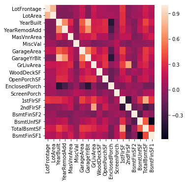

```python
#Correlation HeatMap
corr = numer.corr()
fig, ax = plt.subplots(figsize=(5,5))
sns_plot = sns.heatmap(corr,
        xticklabels=corr.columns,
        yticklabels=corr.columns,
        ax = ax
       )
```

We notice there is a high correlation between:  
1) LotFrontage and LotArea  
2) YearBuilt, YearRemodAdd, GarageArea, GarageBuilt  
3) GrLivArea and 2ndFloor  
4) 1stFloor, BsmtUnfSF, BsmtUnfSF and TotalBsmtSF  
Therefore we only keep ["LotArea", "YearBuilt", "MasVnrArea","MiscVal","GrLivArea", "WoodDeckSF","OpenPorchSF","ScreenPorch","EnclosedPorch","TotalBsmtSF"]

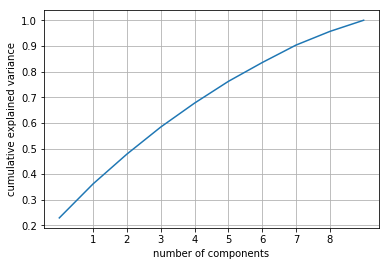

```python
from sklearn.decomposition import PCA
#We only keep the following features
col_final = ["LotArea", "YearBuilt", "MasVnrArea","MiscVal","GrLivArea", "WoodDeckSF","OpenPorchSF","ScreenPorch","EnclosedPorch","TotalBsmtSF"]
final_numer = numer.loc[:,col_final]
final_numer = StandardScaler().fit_transform(final_numer)
#We evaluate the PCA dimension reduction
pca = PCA()
pca.fit(final_numer)
plt.figure(figsize=(6,4))
plt.plot(np.cumsum(pca.explained_variance_ratio_))
plt.grid()
plt.xticks(range(1, 9))
plt.xlabel('number of components')
plt.ylabel('cumulative explained variance');
```

```python
#We create the 7 PCA components
pca = PCA(n_components=7)
principalComponents = pca.fit_transform(final_numer)
final_train = pd.DataFrame(data = principalComponents,
                           index=train_data_clean.index, columns =
                           ['principal component 1', 'principal component 2','principal component 3',
                            'principal component 4', 'principal component 5', 'principal component 6',
                            'principal component 7'])
```

```python
final_train[:5]
```

|  | principal component 1 | principal component 2 | principal component 3 | principal component 4 | principal component 5 | principal component 6 | principal component 7 |
| --- | --- | --- | --- | --- | --- | --- | --- |
| 0 | 1.204273 | -0.024308 | -0.034327 | 0.919118 | -0.264573 | 0.319246 | 0.069975 |
| 1 | 0.805479 | 0.242212 | -0.800952 | -2.368781 | 0.563051 | -0.392287 | 0.184666 |
| 3 | -2.241080 | 3.047247 | -1.958370 | 1.456166 | 0.394844 | 0.662910 | -0.209374 |
| 8 | -1.500489 | 1.522059 | -1.496994 | 0.919943 | 1.066592 | 0.336345 | -0.359596 |
| 9 | -1.193459 | -0.118179 | 0.101908 | -0.264557 | -0.391478 | -0.332705 | -0.450373 |

```python
#Implementation of V Cramers
#Src: https://stackoverflow.com/questions/20892799/using-pandas-calculate-cram%C3%A9rs-coefficient-matrix
def cramers_corrected_stat(confusion_matrix):
    """ calculate Cramers V statistic for categorial-categorial association.
        uses correction from Bergsma and Wicher,
        Journal of the Korean Statistical Society 42 (2013): 323-328
    """
    chi2 = ss.chi2_contingency(confusion_matrix)[0]
    n = confusion_matrix.sum().sum()
    phi2 = chi2/n
    r,k = confusion_matrix.shape
    phi2corr = max(0, phi2 - ((k-1)*(r-1))/(n-1))
    rcorr = r - ((r-1)**2)/(n-1)
    kcorr = k - ((k-1)**2)/(n-1)
    return np.sqrt(phi2corr / min( (kcorr-1), (rcorr-1)))
```

```python
#We create correlation Map according to V Cramer's metric for categorical features
corr = pd.DataFrame(columns=categorical,index= categorical)
for i in range(len(categorical)):
    for j in range(i,len(categorical)):
        if i==j:
            corr.iloc[i,j]=1
        else:
            column1 = categorical[i]
            column2 = categorical[j]
            confusion_matrix = pd.crosstab(categ[column1], categ[column2])
            corr.iloc[i,j]= cramers_corrected_stat(confusion_matrix)
            corr.iloc[j,i]= cramers_corrected_stat(confusion_matrix)
```

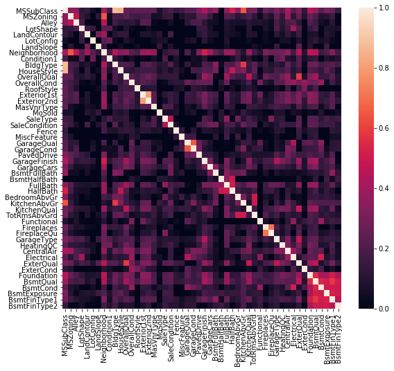

```python
# plot the heatmap
for col in corr.columns:
    corr[col] = pd.to_numeric(corr[col])
fig, ax = plt.subplots(figsize=(9,8))
sns_plot = sns.heatmap(corr,
        xticklabels=corr.columns,
        yticklabels=corr.columns,
        ax = ax
       )
```

We repeat the same process here to reduce the number variables according to dependancy:  
1) MSSubClass, BldgType and HouseStyle  
2) MSZoning and Neighborhood  
3) GarageType and ExterQual  
4) Exterior 1st and Exterior 2d  
5) Sale Type and Sale Condition  
8) GarageQual and GarageCond  
9) FullBath, BsmtHalfBath and HalfBath  
10) BedRoomAbvGrd, KitchenAbvGrd and TotRmsAbvGrd  
11) Fireplaces and FireplaceQu  
12) Foundation, BsmtQual, BsmtCond, BsmtExposure, BsmtFinType1 and BsmtFinType2  
13) Electrical and Central Air  
14) OverallQual, KitchenQual and ExterQual 15) GarageCars and GargeFinish We end up with ["MSSubClass","MSZoning","Alley","LotShape","LandContour","LotConfig","LandSlope","Condition1","OverallQual","OverallCond","GarageFinish","RoofStyle","Exterior1st","MasVnrType","MoSold","SaleType","Fence","MiscFeature","GarageQual","PavedDrive","GargeFinish","FullBath","TotRmsAbvGrd","Functional","FireplaceQu","HeatingQC","Electrical","HeatingQC","ExterCond","Foundation"]  
Now we use a random forst as a feature extractor.

```python
categ_final = ["MSSubClass","MSZoning","Alley","LotShape","LandContour","LotConfig","LandSlope","Condition1","OverallQual","OverallCond",
               "GarageFinish","RoofStyle","Exterior1st","MasVnrType","MoSold","SaleType","Fence","MiscFeature","GarageQual","PavedDrive",
               "FullBath","TotRmsAbvGrd","Functional","FireplaceQu","HeatingQC","Electrical","ExterCond","Foundation"]
final_categ= categ.loc[:,categ_final]
y= out

#Feature Selection for categorical features
X_train,X_test,y_train,y_test = train_test_split(final_categ,y,test_size=0.3)
forest = RandomForestClassifier(n_estimators = 100)
forest.fit(X_train,y_train)
sel = SelectFromModel(forest)
sel.fit(X_train, y_train)
```

```
SelectFromModel(estimator=RandomForestClassifier(bootstrap=True, class_weight=None, criterion='gini',
            max_depth=None, max_features='auto', max_leaf_nodes=None,
            min_impurity_decrease=0.0, min_impurity_split=None,
            min_samples_leaf=1, min_samples_split=2,
            min_weight_fraction_leaf=0.0, n_estimators=100, n_jobs=1,
            oob_score=False, random_state=None, verbose=0,
            warm_start=False),
        norm_order=1, prefit=False, threshold=None)
```

[output not shown]

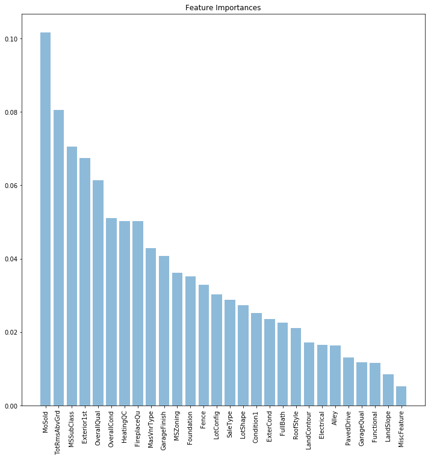

```python
importances = forest.feature_importances_
# get sort indices in descending order
indices = np.argsort(importances)[::-1]
plt.figure(figsize=(12,12))
plt.title('Feature Importances')
plt.bar(range(X_train.shape[1]),
        importances[indices],
        align='center',
        alpha=0.5)
plt.xticks(range(X_train.shape[1]),
           final_categ.columns.values[indices], rotation=90)
plt.plot()
```

```python
selected_feat= X_train.columns[(sel.get_support())]
print(selected_feat)
```

```
Index(['MSSubClass', 'MSZoning', 'OverallQual', 'OverallCond', 'GarageFinish',
       'Exterior1st', 'MasVnrType', 'MoSold', 'TotRmsAbvGrd', 'FireplaceQu',
       'HeatingQC'],
      dtype='object')
```

We keep the previous list of features.

```python
final_categ = final_categ.loc[:,selected_feat]
final_categ[:5]
```

|  | MSSubClass | MSZoning | OverallQual | OverallCond | GarageFinish | Exterior1st | MasVnrType | MoSold | TotRmsAbvGrd | FireplaceQu | HeatingQC |
| --- | --- | --- | --- | --- | --- | --- | --- | --- | --- | --- | --- |
| 0 | 1 | 1 | 1 | 1 | 1 | 1 | 1 | 1 | 1 | 0 | 1 |
| 1 | 2 | 1 | 2 | 2 | 1 | 2 | 2 | 2 | 2 | 1 | 1 |
| 3 | 3 | 1 | 1 | 1 | 2 | 3 | 2 | 1 | 3 | 2 | 2 |
| 8 | 4 | 2 | 1 | 1 | 2 | 5 | 2 | 8 | 1 | 1 | 2 |
| 9 | 5 | 1 | 4 | 3 | 1 | 2 | 2 | 9 | 5 | 1 | 1 |

```python
final_train = final_train.join(final_categ)
final_train = final_train.join(out)
final_train[:5]
```

|  | principal component 1 | principal component 2 | principal component 3 | principal component 4 | principal component 5 | principal component 6 | principal component 7 | MSSubClass | MSZoning | OverallQual | OverallCond | GarageFinish | Exterior1st | MasVnrType | MoSold | TotRmsAbvGrd | FireplaceQu | HeatingQC | SalePrice |
| --- | --- | --- | --- | --- | --- | --- | --- | --- | --- | --- | --- | --- | --- | --- | --- | --- | --- | --- | --- |
| 0 | 1.204273 | -0.024308 | -0.034327 | 0.919118 | -0.264573 | 0.319246 | 0.069975 | 1 | 1 | 1 | 1 | 1 | 1 | 1 | 1 | 1 | 0 | 1 | 208500 |
| 1 | 0.805479 | 0.242212 | -0.800952 | -2.368781 | 0.563051 | -0.392287 | 0.184666 | 2 | 1 | 2 | 2 | 1 | 2 | 2 | 2 | 2 | 1 | 1 | 181500 |
| 3 | -2.241080 | 3.047247 | -1.958370 | 1.456166 | 0.394844 | 0.662910 | -0.209374 | 3 | 1 | 1 | 1 | 2 | 3 | 2 | 1 | 3 | 2 | 2 | 140000 |
| 8 | -1.500489 | 1.522059 | -1.496994 | 0.919943 | 1.066592 | 0.336345 | -0.359596 | 4 | 2 | 1 | 1 | 2 | 5 | 2 | 8 | 1 | 1 | 2 | 129900 |
| 9 | -1.193459 | -0.118179 | 0.101908 | -0.264557 | -0.391478 | -0.332705 | -0.450373 | 5 | 1 | 4 | 3 | 1 | 2 | 2 | 9 | 5 | 1 | 1 | 118000 |

## Prediction

We now try different models on our cleaned data and try to find the best one.

```
Text(0,0.5,'RMSE')
```

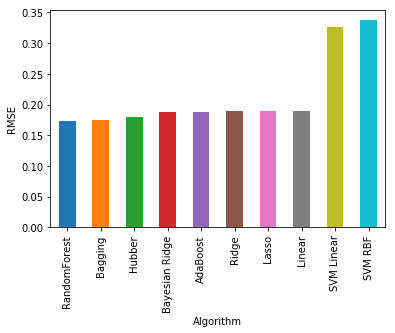

```python
from sklearn.model_selection import KFold
from sklearn.ensemble import BaggingRegressor
from sklearn.ensemble import RandomForestRegressor
from sklearn.ensemble import AdaBoostRegressor
from sklearn import svm
from sklearn.model_selection import cross_val_score
from sklearn.tree import DecisionTreeRegressor
from sklearn.model_selection import GridSearchCV
from sklearn import linear_model

def lets_try(train,labels):
    results={}
    def test_model(clf):

        cv = KFold(n_splits=5,shuffle=True,random_state=45)
        rmse_score = np.sqrt(-cross_val_score(clf, train, labels, cv=cv,scoring="neg_mean_squared_log_error"))
        scores=[rmse_score.mean()]
        return scores

    clf = linear_model.LinearRegression()
    results["Linear"]=test_model(clf)

    clf = linear_model.Ridge()
    results["Ridge"]=test_model(clf)

    clf = linear_model.BayesianRidge()
    results["Bayesian Ridge"]=test_model(clf)

    clf = linear_model.HuberRegressor()
    results["Hubber"]=test_model(clf)

    clf = linear_model.Lasso(alpha=1e-4)
    results["Lasso"]=test_model(clf)

    clf = BaggingRegressor()
    results["Bagging"]=test_model(clf)

    clf = RandomForestRegressor()
    results["RandomForest"]=test_model(clf)

    clf = AdaBoostRegressor()
    results["AdaBoost"]=test_model(clf)

    clf = svm.SVR()
    results["SVM RBF"]=test_model(clf)

    clf = svm.SVR(kernel="linear")
    results["SVM Linear"]=test_model(clf)

    results = pd.DataFrame.from_dict(results,orient='index')
    results.columns=["RMSE"]
    results.RMSE.astype('float')
    return results
X = final_train.drop(columns="SalePrice")
y = final_train["SalePrice"]
results = lets_try(X,y)
results=results.sort_values(by=["RMSE"],ascending=True)
results.RMSE.plot(kind='bar')
plt.xlabel("Algorithm")
plt.ylabel("RMSE")
```

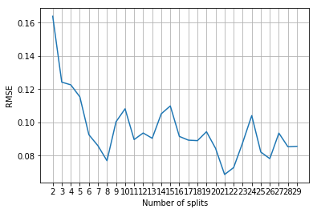

```python
from sklearn.model_selection import KFold
from sklearn.metrics import mean_squared_log_error
from math import sqrt
#Cross Validation

def avrkfold(clf, X, y, test,n):
    #We create folds of 15 splits
    kf = KFold(n_splits=n, random_state=None, shuffle=False)
    models = []
    scores = []
    #We generate a model for each validation fold
    for train_index, test_index in kf.split(X,y):
        X_train, X_test = X.iloc[train_index], X.iloc[test_index]
        y_train, y_test = y.iloc[train_index], y.iloc[test_index]
        clf.fit(X_train,y_train)
        predictions = clf.predict(X_test)
        models.append(clf)
        rmse = sqrt(mean_squared_log_error(y_test, predictions))
        scores.append(rmse)
    #We attribute a weight for each model based on their score
    weights = np.array(scores) / sum(scores)
    #we estimate the price
    prediction = [models[i].predict(test)*weights[i] for i in range(n)]
    s = np.array([0.0]*test.shape[0])
    for i in range(len(prediction)):
        s+= prediction[i]
    #We sum the weighted predictions
    prediction = s
    return prediction

# clfs =  [linear_model.LinearRegression(),linear_model.Ridge(),linear_model.BayesianRidge(),linear_model.HuberRegressor(),linear_model.Lasso(alpha=1e-4),BaggingRegressor(),
#          RandomForestRegressor(),AdaBoostRegressor()]
clfs = [BaggingRegressor()]
a=[]
#We try to determine the best number of folds for the cross fold
for n in range(2,30):
    predictions = []
    scores = []
    X_train,X_test,y_train,y_test = train_test_split(X,y,test_size=0.3)
    for clf in clfs:
        prediction = avrkfold(clf,X,y,X_test,n)
        predictions.append(prediction)
        rms = sqrt(mean_squared_log_error(y_test, prediction))
        scores.append(rms)
    weights = np.array(scores) / sum(scores)
    s = np.array([0.0]*y_test.shape[0])
    for i in range(len(predictions)):
        s+= predictions[i]*weights[i]
    predictions_final = s
    a.append(sqrt(mean_squared_log_error(y_test, predictions_final)))

plt.plot(range(2,30),a)
plt.xlabel("Number of splits")
plt.ylabel("RMSE")
plt.xticks(range(2,30))
plt.grid()
```

```python
predictions = []
scores = []
X_train,X_test,y_train,y_test = train_test_split(X,y,test_size=0.3)
for clf in clfs:
    prediction = avrkfold(clf,X,y,X_test,22)
    predictions.append(prediction)
    rms = sqrt(mean_squared_log_error(y_test, prediction))
    scores.append(rms)
weights = np.array(scores) / sum(scores)
s = np.array([0.0]*y_test.shape[0])
for i in range(len(predictions)):
    s+= predictions[i]*weights[i]
predictions_final = s
```

```python
sqrt(mean_squared_log_error(y_test, predictions_final))
```

```
0.07499823245348847
```

```python
final_numer = test_data.loc[:,col_final]
final_numer = StandardScaler().fit_transform(final_numer)
#We evaluate the PCA dimension reduction
principalComponents = pca.fit_transform(final_numer)
test_final = pd.DataFrame(data = principalComponents,
               index=test_data.index, columns =
               ['principal component 1', 'principal component 2','principal component 3',
                'principal component 4', 'principal component 5', 'principal component 6',
                'principal component 7'])
test_final = test_final.join(test_data.loc[:,selected_feat])
```

```python
a=[]
for clf in clfs:
    prediction = avrkfold(clf,X,y,test_final,22)
    a.append(prediction)
s = np.array([0.0]*test_final.shape[0])
for i in range(len(a)):
    s+= a[i]*weights[i]
predictions_final_test = s
```

We create our final DataFrame for the test data.

```python
data_to_submit = pd.DataFrame()
data_to_submit["Id"] = test_data["Id"]
data_to_submit["SalePrice"]=predictions_final_test
```

```python
data_to_submit.to_csv('csv_to_submit.csv', index = False)
```